# Count Regression Model Dominance Analysis

Analysis Documentation in Support of Manuscript

Joseph Luchman

This notebook provides documentation for the generation of the data used in the manuscript **Relative Importance Analysis for Count Regression Models**.

This document extends on the main manuscript by focusing more closely on implementation details. These implementation details are are not essential for the reader to understand the manuscript but are essential for reproducibility of the results. The details in this notebook also add additional context to the manuscript’s analyses by, for example, extending the Poisson regression results reported to negative Binomial regression.

# Data Generation

The manuscript describes four simulated tailoring shop characteristics that will be used in the analysis as IVs. These IVs are:

1. equipment reliability or *ER*
2. assistant staffing levels or *AS*
3. tailor skill level or *SL*
4. tailor work experience or *WE*

My approach in generating the IV data for this manuscript was to begin by developing higher-order population parameters that would produce a specific result from a linear regression. The data as generated were only to be based loosely on this higher-order conceptual structure and the population parameters actually used to generate the data were sampled, and thus varied, from it in a way that was not intended to be directly under my control. As such, the results would follow from the higher order conceptual structure imposed on the data but not be completely determined by me.

## Generate IV Data

The generation of the four IVs began with setting up a higher-order population-level covariance matrix of four tailoring shop IVs. This higher-order variance-covariance matrix was to be applied as a parameter for data generation in an inverse Wishart variate generating function as the scale matrix parameter.

### Higher-Order Variance-Covariance Structure

The variances chosen were four equally-spaced values between standard deviation values of 1 and 2. The first IV, *ER*, had a $\sigma_{ER} = 1.00$ and $\sigma^2_{ER} = 1.00$. The second IV, *AS*, had $\sigma_{AS} = 1.33$ and $\sigma^2_{AS} = 1.78$. *SL* had $\sigma_{SL} = 1.67$ and $\sigma^2_{SL} = 2.78$. Finally, *WE* had $\sigma_{WE} = 2.00$ and $\sigma^2_{WE} = 4.00$.

The covariances values chosen were “balanced” across IVs such that the total redundancy for any one IV was identical to the others. The six correlations between the four IVs were designed to take on one of three values .250, .125, and .063 with the following values specified between each of the specific IVs: $r_{ER,AS} = .250$, $r_{ER,SL} = .125$, $r_{ER,WE} = .063$, $r_{AS,SL} = .063$, $r_{AS,WE} = .125$, and $r_{SL,WE} = .250$.

The code block below constructs and reports on the correlation matrix as well as the the variance-covariance matrix on which it is based.

```r
namelist <- c("ER", "AS", "SL", "WE")

Covariance_Matrix <-
  c(1,
    .5^(2:4)*sqrt(1*c((4/3)^2, (5/3)^2, 4))*sqrt(1),
    .5^2*sqrt(1)*sqrt(1*(4/3)^2),
    (4/3)^2,
    .5^(4:3)*sqrt(1*(4/3)^2)*sqrt(1*c((5/3)^2, 4)),
    .5^(3:4)*sqrt(1*(5/3)^2)*sqrt(1*c(1, (4/3)^2)),
    (5/3)^2,
    .5^2*sqrt(1*(5/3)^2)*sqrt(1*4),
    .5^(4:2)*sqrt(1*4)*sqrt(1*c(1, (4/3)^2, (5/3)^2)),
    4) |>
  matrix(nrow = 4, byrow = TRUE, dimnames = list(namelist, namelist))

Covariance_Matrix |>
  as.data.frame() |>
  gt(rownames_to_stub = TRUE) |>
  tab_header("Table S1: Higher-order Population Covariance Matrix") |>
  fmt_number(columns = 2:5, decimals = 4)
```

Table S1: Higher-order Population Covariance Matrix

|  | ER | AS | SL | WE |
| --- | --- | --- | --- | --- |
| ER | 1.0000 | 0.3333 | 0.2083 | 0.1250 |
| AS | 0.3333 | 1.7778 | 0.1389 | 0.3333 |
| SL | 0.2083 | 0.1389 | 2.7778 | 0.8333 |
| WE | 0.1250 | 0.3333 | 0.8333 | 4.0000 |

```r
Covariance_Matrix |>
  cov2cor() |>
  as.data.frame() |>
  gt(rownames_to_stub = TRUE) |>
  tab_header("Table S2: Higher-order Population Correlation Matrix")
```

Table S2: Higher-order Population Correlation Matrix

|  | ER | AS | SL | WE |
| --- | --- | --- | --- | --- |
| ER | 1.0000 | 0.2500 | 0.1250 | 0.0625 |
| AS | 0.2500 | 1.0000 | 0.0625 | 0.1250 |
| SL | 0.1250 | 0.0625 | 1.0000 | 0.2500 |
| WE | 0.0625 | 0.1250 | 0.2500 | 1.0000 |

### Sampled Population Parameter Values

The population parameters for use in generating data were sampled as one draw from an inverse Wishart distribution with the higher-order variance-covariance matrix as the scale parameter and a degrees of freedom parameter of 100. The large value for the degrees of freedom was chosen as it has the effect of reducing the variances of each element of the sampled matrix which stabilizes the correlations of the values sampled to be closer to the scale matrix’s values.

The code block below takes the variance-covariance matrix sample and reports on the sampled values as well as the correlation matrix of the sampled values.

```r
Covariance_Matrix_Use <- riwish(100, Covariance_Matrix)*100

Covariance_Matrix_Use |>
  as.data.frame() |>
  gt(rownames_to_stub = TRUE) |>
  tab_header("Table S3: Sampled Population Covariance Matrix") |>
  fmt_number(columns = 2:5, decimals = 4)
```

Table S3: Sampled Population Covariance Matrix

|  | ER | AS | SL | WE |
| --- | --- | --- | --- | --- |
| ER | 1.3958 | 0.7098 | 0.2837 | 0.4952 |
| AS | 0.7098 | 2.1036 | 0.4193 | 0.7998 |
| SL | 0.2837 | 0.4193 | 2.3822 | 0.9449 |
| WE | 0.4952 | 0.7998 | 0.9449 | 3.7205 |

```r
Covariance_Matrix_Use |>
  cov2cor() |>
  as.data.frame() |>
  gt(rownames_to_stub = TRUE) |>
  tab_header("Table S4: Sampled Population Correlation Matrix") |>
  fmt_number(columns = 2:5, decimals = 4)
```

Table S4: Sampled Population Correlation Matrix

|  | ER | AS | SL | WE |
| --- | --- | --- | --- | --- |
| ER | 1.0000 | 0.4142 | 0.1556 | 0.2173 |
| AS | 0.4142 | 1.0000 | 0.1873 | 0.2859 |
| SL | 0.1556 | 0.1873 | 1.0000 | 0.3174 |
| WE | 0.2173 | 0.2859 | 0.3174 | 1.0000 |

Note that the sampled variance-covariance matrix is multiplied by 100 as it has values that are around $1/100$ of the values of the original matrix due to the degrees of freedom parameter.

### Generate Observed Data

The analysis data were generated as random draws from a Multivariate Normal distribution using the sampled population parameters in the previous step as a variance-covariance matrix.

The number of observations in the sample was also determined using a single draw from a random uniform distribution that was required to range between 5,000 and 10,000. This range of observations that was chosen as it should allow for stable estimates from these data yet be within a range observed of many large social surveys.

The code block below samples the sample size value and takes all IV samples. The block also reports on descriptive statistics from the sampled IV observations including the sample size.

```r
total_n <-
  runif(n = 1, min = 5000, max = 10000) |>
  round()

Data_Frame <-
  mvrnorm(n = total_n,
          mu = rep(0, times = 4),
          Sigma = Covariance_Matrix_Use) |>
  as.data.frame() |>
  set_names(namelist)

Data_Frame |>
  summarise(
    across(everything(), .fns = mean),
    ) |>
  pivot_longer(everything(), names_to = "IV Name", values_to = "Mean") |>
  left_join(
  Data_Frame |>
  summarise(
    across(everything(), .fns = sd),
    ) |>
    pivot_longer(
      everything(),
      names_to = "IV Name",
      values_to = "Standard Deviation"
    )
  ) |>
  left_join(
    Data_Frame |>
      cor() |>
      as_tibble(rownames = "IV Name")
  ) |>
  gt(rowname_col = "IV Name") |>
  tab_header("Table S5: Sampled Data Descriptive Statistics") |>
  fmt_number(columns = 2:7, decimals = 4) |>
  tab_spanner(columns = c(ER, AS, SL, WE), label = "Correlations") |>
  tab_style(
    style = cell_borders(sides = "right"),
    locations = cells_body(columns = "Standard Deviation")
  ) |>
  tab_source_note(
    str_c(
      "Sample Size of Simulated Data is ",
      nrow(Data_Frame) |>
        format(big.mark = ","),
      "."
    )
  )
```

Table S5: Sampled Data Descriptive Statistics

|  | Mean | Standard Deviation | Correlations ER | Correlations AS | Correlations SL | Correlations WE |
| --- | --- | --- | --- | --- | --- | --- |
| ER | −0.0355 | 1.1853 | 1.0000 | 0.4168 | 0.1446 | 0.2180 |
| AS | −0.0261 | 1.4494 | 0.4168 | 1.0000 | 0.1958 | 0.2850 |
| SL | −0.0056 | 1.5480 | 0.1446 | 0.1958 | 1.0000 | 0.3295 |
| WE | 0.0144 | 1.9211 | 0.2180 | 0.2850 | 0.3295 | 1.0000 |

Sample Size of Simulated Data is 6,780.

## Generate Dependent Variables

This section creates multiple count DVs from a single Normally distributed DV. The Normally distributed DV is generated first and is then used to determine the values of other count DVs. This method is used as it allows more control over the magnitudes of relationships between the count DV’s with the IVs.

### Generate Normally Distributed Dependent Variable

The generation of the Normally distributed variable extended from the methodology that was established above where a set of higher-order population parameters are first set and adjusted using a draws from a specific distribution to reduce the effect of my decisions on the results.

Conceptually, the underlying Normally distributed variable can be thought of as a latent propensity each tailoring shop has for making more garments. This garment propensity variable (called $GP$) is generated as a linear combination of the four tailoring shop IVs. In devising the higher-order population coefficients, I thought it would be convenient to generate coefficients that, when combined with the higher-order population variances, would produce a specific $R^2$ under idealized conditions. In generating these coefficients, I intentionally ignored the higher-order population covariances to allow this section to be easier to follow and because I was not so much trying to attain a specific $R^2$ in the observed data but rather to have a reasonable, systematic approach to generating IV coefficient values.

#### Higher-Order Population Parameters

The code block below sets the higher order IV coefficient population parameters and reports on their values.

```r
Coefficient_Vector <- c(.2, sqrt(.04/(4/3)^2), sqrt(.04/(5/3)^2), .1)

Coefficient_Vector |>
  data.frame(name = namelist, value = _) |>
  pivot_wider(id_cols = everything()) |>
  gt() |>
  tab_header("Table S6: Higher-order Population Coefficient Values") |>
  fmt_number(columns = 1:4, decimals = 4)
```

Table S6: Higher-order Population Coefficient Values

| ER | AS | SL | WE |
| --- | --- | --- | --- |
| 0.2000 | 0.1500 | 0.1200 | 0.1000 |

#### Sampled Population Parameters

The higher-order population values were used as the means in four draws from a Normal distribution each with a standard deviation of .05 to obtain coefficients. As the higher-order coefficient parameters were all within a relatively narrow range, the standard deviation of .05 allowed for the possibility that, by chance, the rank ordering of coefficient magnitudes could change.

The code block below implements the sampling of the coefficient values and reports on their values.

```r
Coefficient_Vector_Use <- rnorm(4, Coefficient_Vector, .05)

names(Coefficient_Vector_Use) <- namelist

Coefficient_Vector_Use |>
  data.frame(name = namelist, value = _) |>
  pivot_wider(id_cols = everything()) |>
  gt() |>
  tab_header("Table S7: Sampled Population Coefficient Values") |>
  fmt_number(columns = 1:4, decimals = 4)
```

Table S7: Sampled Population Coefficient Values

| ER | AS | SL | WE |
| --- | --- | --- | --- |
| 0.2662 | 0.1270 | 0.1084 | 0.1184 |

The sampled population coefficients varied from the higher-order values and varied from the higher-order coefficients’ rank order as $\beta_{WE} > \beta_{SL}$ in the sampled values whereas the reverse was true of the higher-order values.

#### Generate Observed Normal Distribution Variable Values

The garment propensity variable $GP$ was generated as a linear combination of the four tailoring shop characteristics and their respective coefficients. The error variance for $GP$ was set to be $1 - \sigma^2_{ER\beta_{ER} + AS\beta_{AS} + SL\beta_{SL} + WE\beta_{WE}}$ thus forcing the variance of $GP$ to be 1. The mean of $GP$ is also set to be 0.

The code block below generates and reports on the descriptive statistics of $GP$.

```r
Data_Frame <-
  Data_Frame |>
  mutate(
    GP =
      ER*Coefficient_Vector_Use[["ER"]] +
      AS*Coefficient_Vector_Use[["AS"]] +
      SL*Coefficient_Vector_Use[["SL"]] +
      WE*Coefficient_Vector_Use[["WE"]],
    GP = GP + rnorm(total_n, 0, sqrt(1 - var(GP)))
  )

Data_Frame |>
  summarise("Mean" = mean(GP)) |>
  bind_cols(
    Data_Frame |>
      summarise("Standard Deviation" = sd(GP))
  ) |>
  bind_cols(
    Data_Frame |>
      cor() |>
      as_tibble(rownames = "IV Name") |>
      filter(`IV Name` == "GP") |>
      select(-GP, -`IV Name`)
  ) |>
  gt() |>
  tab_header("Table S8: Garment Propensity Descriptive Statistics") |>
  fmt_number(columns = 1:6, decimals = 4) |>
  tab_spanner(columns = c(ER, AS, SL, WE), label = "Correlations") |>
  tab_style(
    style = cell_borders(sides = "right"),
    locations = cells_body(columns = "Standard Deviation")
  )
```

Table S8: Garment Propensity Descriptive Statistics

| Mean | Standard Deviation | Correlations ER | Correlations AS | Correlations SL | Correlations WE |
| --- | --- | --- | --- | --- | --- |
| −0.0105 | 1.0134 | 0.4596 | 0.4033 | 0.3208 | 0.4136 |

In addition, a histogram of $GP$ is reported.

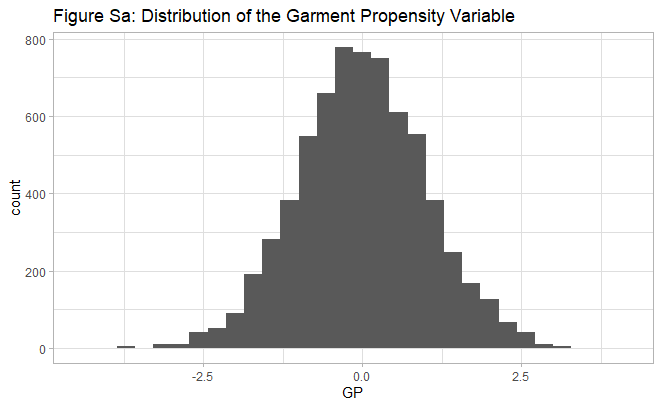

```r
Data_Frame |>
  select(GP) |>
  ggplot(aes(x = GP)) +
  stat_bin() +
  ggtitle("Figure Sa: Distribution of the Garment Propensity Variable") +
  theme_light()
```

Finally, a regression predicting $GP$ using the four tailoring shop IVs is estimated and reported on below to confirm that the sampled population coefficient values are re-obtainable in the data.

```r
lm(GP ~ ., data = Data_Frame) |>
  parameters() |>
  select(-df_error, -CI) |>
  rename(Low = "CI_low", High = "CI_high") |>
  gt(rowname_col = "Parameter") |>
  fmt_number(columns = 2:7, decimals = 4) |>
  tab_spanner(columns = c(Low, High), label = "Confidence Interval") |>
  tab_header("Table S9: Garment Propensity Linear Regression")
```

Table S9: Garment Propensity Linear Regression

[output not shown]

The results confirm that the coefficients are recoverable in the data.

### Generate Poisson Dependent Variable

$SJ$ was given a mean of 1 was chosen to make the $SJ$ results as close to those from $GP$ as possible; using this approach both DVs will have variances of 1.

The code block below implements the translation process and reports on the descriptive results.

```r
Data_Frame <-
  Data_Frame |>
  mutate(
    SJ =
      GP |>
      pnorm(log.p = TRUE) |>
      qpois(1, log.p = TRUE)
  )

Data_Frame |>
  summarise("Mean" = mean(SJ)) |>
  bind_cols(
    Data_Frame |>
      summarise("Standard Deviation" = sd(SJ))
  ) |>
  bind_cols(
    Data_Frame |>
      cor() |>
      as_tibble(rownames = "IV Name") |>
      filter(`IV Name` == "SJ") |>
      select(-SJ, -GP, -`IV Name`)
  ) |>
  gt() |>
  tab_header("Table S10: Poisson Dependent Variable Descriptive Statistics") |>
  fmt_number(columns = 1:6, decimals = 4) |>
  tab_spanner(columns = c(ER, AS, SL, WE), label = "Correlations") |>
  tab_style(
    style = cell_borders(sides = "right"),
    locations = cells_body(columns = "Standard Deviation")
  )
```

Table S10: Poisson Dependent Variable Descriptive Statistics

| Mean | Standard Deviation | Correlations ER | Correlations AS | Correlations SL | Correlations WE |
| --- | --- | --- | --- | --- | --- |
| 0.9940 | 1.0082 | 0.4175 | 0.3592 | 0.2913 | 0.3726 |

In addition, a histogram of $SJ$ is provided below.

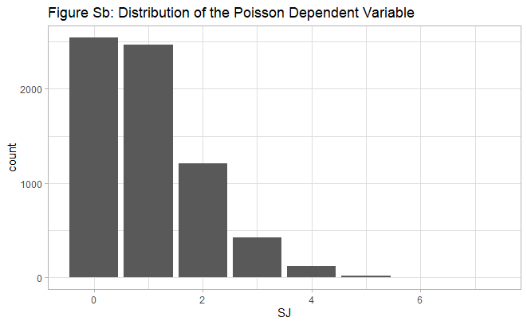

```r
Data_Frame |>
  select(SJ) |>
  ggplot(aes(x = SJ)) +
  stat_count() +
  ggtitle("Figure Sb: Distribution of the Poisson Dependent Variable") +
  theme_light()
```

### Generate Negative Binomial Dependent Variable

The negative Binomial distributed variable related to the number of overcoats produced (i.e., $OC$) was also based on the garment propensity variable translated to the negative Binomial distribution using the cumulative propensity to quantile method.

The generation of the $OC$ also sought to ensure as much similarity to the $GP$ variable as possible while also requiring that $OC$’s distribution fail to meet the assumptions of the Poisson distribution. The quantile function values that $GP$ was translated into were then a *size* parameter of .5 and *mu* parameter of 1.

This combination of *size* and *mu* parameters result in a mean (i.e., the *mu*/$\mu$ value) of 1 but a variance that substantially exceeded 1; in this case or a value of 3 as $\sigma^{2} = \mu + \frac{\mu^2}{size}$.

The code block below implements the translation process and reports on the descriptive results.

```r
Data_Frame <-
  Data_Frame |>
  mutate(
    OC = GP |>
      pnorm(log.p = TRUE) |>
      qnbinom(size = .5, mu = 1, log.p = TRUE)
  )

Data_Frame |>
  summarise("Mean" = mean(OC)) |>
  bind_cols(
    Data_Frame |>
      summarise("Standard Deviation" = sd(OC))
  ) |>
  bind_cols(
    Data_Frame |>
      cor() |>
      as_tibble(rownames = "IV Name") |>
      filter(`IV Name` == "OC") |>
      select(-SJ, -GP, -`IV Name`, -OC)
  ) |>
  gt() |>
  tab_header("Table S11: Negative Binomial Dependent Variable Descriptive Statistics") |>
  fmt_number(columns = 1:6, decimals = 4) |>
  tab_spanner(columns = c(ER, AS, SL, WE), label = "Correlations") |>
  tab_style(
    style = cell_borders(sides = "right"),
    locations = cells_body(columns = "Standard Deviation")
  )
```

[output not shown]

```r
Data_Frame |>
  select(OC) |>
  ggplot(aes(x = OC)) +
  stat_count() +
  ggtitle("Figure Sc: Distribution of the Negative Binomial Dependent Variable") +
  theme_light()
```

[output not shown]

## Report Primary Generated Data Descriptive Statistics

This section produces Table 4 in the manuscript including the descriptive statistics for all four IVs and the $SJ$ DV reported on in the manuscript.

```r
Data_Frame |>
  summarise(across(everything(), mean)) |>
  pivot_longer(everything(), names_to = "Variable", values_to = "Mean") |>
  left_join(
    Data_Frame |>
      summarise(across(everything(), sd)) |>
      pivot_longer(everything(), names_to = "Variable",
                   values_to = "Standard Deviation"),
    by = "Variable"
  ) |>
  left_join(
    Data_Frame |>
      cor() |>
      as_tibble(rownames = "Variable"),
    by = "Variable"
  ) |>
  filter(!(Variable %in% c("GP", "OC"))) |>
  select(-GP, -OC) |>
  gt() |>
  tab_header("Table 4: Descriptive Statistics") |>
  fmt_number(columns = 2:8, decimals = 4) |>
  tab_spanner(columns = c(ER, AS, SL, WE, SJ), label = "Correlations") |>
  tab_style(
    style = cell_borders(sides = "right"),
    locations = cells_body(columns = "Standard Deviation")
  ) |>
  print() |>
  gtsave(filename = "descrips_initial.tex", path = "./includes/")
```

[output not shown]

# Primary Modeling

This section describes the model estimation and dominance analysis of the primary analysis models involving the primary $SJ$ and the unreported $OC$ DVs.

## Modeling Sport Jacket Production

All modeling and reporting of $SJ$ is implemented in this section.

### Obtain Modeling Results

The code block below estimates, formats, and reports on the Poisson regression with $SJ$.

These results are used in Table 5 of the manuscript.

```r
SJ_pois_reg <-
  glm(SJ ~ ER + AS + SL + WE,
      data = Data_Frame,
      family = poisson()
      )

SJ_pois_param <-
  SJ_pois_reg |>
  parameters()

SJ_pois_param  |>
  select(-df_error, -CI, -z, -p) |>
  {bind_rows(slice_tail(., n = 4), slice_head(., n = 1))} |>
  rename(Low = "CI_low", High = "CI_high",
         B = "Coefficient", `\\sigma_{B}` = "SE") |>
  mutate(`e^B` = exp(B),
         Parameter = str_replace(Parameter, "\\(Intercept\\)", "Intercept")) |>
  gt(rowname_col = "Parameter") |>
  fmt_number(columns = 2:6, decimals = 4) |>
  tab_spanner(columns = c(Low, High), label = "95% Confidence Interval") |>
  tab_header("Table 5: Poisson Regression Predicting Sport Jackets Produced") |>
  print() |>
  gtsave(filename = "poisson_coeff.tex", path = "./includes/")
```

[output not shown]

```r
map(c("ER", "AS", "SL", "WE"),
    \(iv) {

      lst <-
        list(-2:2) |>
        set_names(iv)

      SJ_pois_reg |>
        emmeans::emmeans(reformulate(iv),
                         at = lst) |>
        as_tibble |>
        rename(mgn = all_of(iv)) |>
        mutate(var = iv |> as_factor,
               emmean = exp(emmean))
    }
) |>
  list_rbind() |>
  ggplot(aes(x = mgn, y = emmean, group = var, color = var)) +
  geom_line() + scale_color_viridis_d() + theme_light() +
  ylab("Predicted Counts") + xlab("Values of Tailoring Characteristic") +
  labs(color = "Tailoring\nCharacteristic") +
  ggtitle("Figure Sd: Marginal Effects of the Sport Jacket\nProduction Model")
```

[output not shown]

### Obtain All Submodels’ R-squares

The code block below captures all sub-model $R^2_{DEV}$ values. The values obtained in this section are used in Table 6 of the manuscript.

```r
IV_subsets <-
  expand_grid(c("ER", ""), c("AS", ""), c("SL", ""), c("WE", "")) |>
  set_names(c("ER", "AS", "SL", "WE")) |>
  mutate(num_per = rowSums(across(everything(), .fns = ~ str_length(.) > 1))) |>
  arrange(num_per, desc(ER), desc(AS), desc(SL), desc(WE)) |>
  select(-num_per) |>
  slice(-1) |>
  t() |>
  as_tibble()

SJ_pois_subsets <-
  map_dbl(IV_subsets,
          \(ivs) {
            discard(ivs, ~ str_length(.) < 2) |>
            reformulate(response = "SJ") |>
              glm(data = Data_Frame, family = poisson()) |>
              r2_kullback(adjust = FALSE)
          }
  )

IV_subset_names <-
  map_chr(IV_subsets,
          \(ivs) {
            discard(ivs, ~ str_length(.) < 2) |>
              str_c(., collapse = " + ")
          }
  )

IV_subset_names |>
  str_c("SJ ~ ", .) |>
  as_tibble() |>
  bind_cols(SJ_pois_subsets) |>
  gt() |>
  tab_header("Table 6: R^2_{DEV} by Sub-model") |>
  fmt_number(columns = 2, decimals = 4) |>
  cols_label(everything() ~ "") |>
  print() |>
  gtsave(filename = "all_subsets.tex", path = "./includes/")
```

[output not shown]

### Dominance Analytic Results

The code block below implements the dominance analysis using $SJ$.

```r
SJ_pois_DA <-
  domir(SJ ~ ER + AS + SL + WE,
        \(fml, ...) {
          res <-
            glm(fml, ...)
          return(r2_kullback(res, adjust = FALSE))
        },
        data = Data_Frame, family = poisson()
  )

SJ_pois_DA |>
  pluck("General_Dominance") |>
  as_tibble(rownames = "Variable") |>
  left_join(SJ_pois_DA |>
              pluck("Standardized") |>
              as_tibble(rownames = "Variable"),
            by = "Variable") |>
  set_names(c("Variable", "General Dominance", "Standardized")) |>
  gt(rowname_col = "Variable") |>
  tab_header("Table S12: Poisson Model General Dominance Statistics") |>
  fmt_number(columns = 2:3, decimals = 4) |>
  tab_source_note(
    str_c("Overall Deviance R-square is ",
          SJ_pois_reg |>
            r2_kullback() |>
            sprintf("%5.4f", .), ".")
  )

SJ_pois_DA |>
  pluck("Conditional_Dominance") |>
  as_tibble(rownames = "Variable") |>
  set_names(c("Variable", str_c("Subset Size: ", 1:4))) |>
  gt(rowname_col = "Variable") |>
  tab_header("Table S13: Poisson Model Conditional Dominance Statistics") |>
  fmt_number(columns = 2:5, decimals = 4)

SJ_pois_DA |>
  pluck("Complete_Dominance") |>
  as_tibble(rownames = "Dominating Variable") |>
  mutate(
    `Dominating Variable` = str_remove(`Dominating Variable`, "Dmnates_")
  ) |>
  set_names(c("Dominating Variable", str_c("Dominated Variable: ",
                                           c("ER", "AS", "SL", "WE")))) |>
  gt(rowname_col = "Dominating Variable") |>
  tab_header("Table S14: Poisson Model Complete Dominance Designations") |>
  sub_missing() |>
  tab_stubhead("Dominating Variable")
```

[output not shown]

The code block below generates and reports on Table 7 in the manuscript.

```r
SJ_pois_DA |>
  pluck("General_Dominance") |>
  as_tibble(rownames = "Variable") |>
  gt(rowname_col = "Variable") |>
  tab_header("Table 7: General Dominance Statistics") |>
  cols_label(everything() ~ "") |>
  fmt_number(columns = 2, decimals = 4) |>
  print() |>
  gtsave(filename = "gen_dom.tex", path = "./includes/")
```

[output not shown]

```r
SJ_pois_DA |>
  pluck("Conditional_Dominance") |>
  as_tibble(rownames = "IV") |>
  pivot_longer(
    cols = starts_with("subset_size"),
    names_to = "Subset Size",
    values_to = "Conditional Dominance Statistic",
    names_prefix = "subset_size_"
    ) |>
  mutate(
    IV = fct_relevel(IV, "ER", "AS", "SL", "WE"),
    `Subset Size` = `Subset Size` |> as.integer
  ) |>
  ggplot(
    aes(x = `Subset Size`, y = `Conditional Dominance Statistic`,
        group = IV, color = IV)
  ) + geom_line() +
  theme_linedraw() +
  labs(linetype = "") +
  coord_trans(xlim = c(.9, 4.1), ylim = c(.015, .185), expand = FALSE, y = "log") +
  theme(legend.position = c(.90, .89),
        legend.box.background = element_rect(color = "black"),
        legend.title = element_blank(), legend.text = element_text(size = 7),
        legend.key.height = unit(7, "pt"), axis.text.y = element_text(size = 7),
        legend.margin = margin(b = .5, l = .5, r = .5),
        axis.title = element_text(family = "serif")
  ) +
  scale_y_continuous(n.breaks = 5) + scale_color_viridis_d()

ggsave("condit_gph.png", height = 4*.75, width = 6*.75,
       units = "in", path = "./includes/")
```

[output not shown]

All modeling and reporting of $OC$ is implemented in this section.

Ultimately, these results were not included in the manuscript as they did not meaningfully extend on the Poisson regression results. They are included here for completeness.

### Obtain Modeling Results

The code block below estimates, formats, and reports on the negative Binomial regression with $OC$. The Theta parameter is included in a footnote.

```r
OC_nb_reg <-
  glm.nb(OC ~ ER + AS + SL + WE,
      data = Data_Frame)

OC_nb_param <-
  OC_nb_reg |>
  parameters()

OC_nb_param  |>
  select(-df_error, -CI, -z, -p) |>
  {bind_rows(slice_tail(., n = 4), slice_head(., n = 1))} |>
  rename(Low = "CI_low", High = "CI_high", B = "Coefficient") |>
  mutate(`e^B` = exp(B),
         Parameter = str_replace(Parameter, "\\(Intercept\\)", "Intercept")) |>
  gt(rowname_col = "Parameter") |>
  fmt_number(columns = 2:6, decimals = 4) |>
  tab_spanner(columns = c(Low, High), label = "95% Confidence Interval") |>
  tab_header("Table S15: Negative Binomial Regression") |>
  tab_source_note(
    str_c("Theta parameter is ",
          OC_nb_reg$theta |>
            format(big.mark = ",", digits = 4), ".")
  )
```

[output not shown]

```r
map(c("ER", "AS", "SL", "WE"),
    \(iv) {

      lst <-
        list(-2:2) |>
        set_names(iv)

      OC_nb_reg |>
        emmeans::emmeans(
          reformulate(iv),
          at = lst
        ) |>
        as_tibble |>
        rename(mgn = all_of(iv)) |>
        mutate(var = iv |>
                 as_factor,
               emmean = exp(emmean))
    }
) |>
  list_rbind() |>
  ggplot(aes(x = mgn, y = emmean, group = var, color = var)) +
  geom_line() + scale_color_viridis_d() + theme_light() +
  ylab("Predicted Counts") + xlab("Values of Tailoring Characteristic") +
  labs(color = "Tailoring\nCharacteristic") +
  ggtitle("Figure Se: Marginal Effects of the Overcoat\nProduction Model")
```

[output not shown]

### Dominance Analytic Results

The code block below implements the dominance analysis using $OC$.

```r
OC_nb_DA <-
  domir(OC ~ ER + AS + SL + WE,
        \(fml, ...) {
          res <-
            glm.nb(fml, ...)
          return(r2_kullback(res, adjust = FALSE))
        },
        data = Data_Frame)

OC_nb_DA |>
  pluck("General_Dominance") |>
  as_tibble(rownames = "Variable") |>
  left_join(OC_nb_DA |>
              pluck("Standardized") |>
              as_tibble(rownames = "Variable"),
            by = "Variable") |>
  set_names(c("Variable", "General Dominance", "Standardized")) |>
  gt(rowname_col = "Variable") |>
  tab_header("Table S16: Negative Binomial Model General Dominance Statistics") |>
  fmt_number(columns = 2:3, decimals = 4) |>
  tab_source_note(str_c("Overall Deviance R-square is ",
                        OC_nb_reg |> r2_kullback(adjust = FALSE) |>
                          sprintf("%5.4f", .), "."))

OC_nb_DA |>
  pluck("Conditional_Dominance") |>
  as_tibble(rownames = "Variable") |>
  set_names(c("Variable", str_c("Subset Size: ", 1:4))) |>
  gt(rowname_col = "Variable") |>
  tab_header("Table S17: Negative Binomial Model Conditional Dominance Statistics") |>
  fmt_number(columns = 2:5, decimals = 4)

OC_nb_DA |>
  pluck("Complete_Dominance") |>
  as_tibble(rownames = "Dominating Variable") |>
  mutate(
    `Dominating Variable` = str_remove(`Dominating Variable`, "Dmnates_")
  ) |>
  set_names(c("Dominating Variable", str_c("Dominated Variable: ",
                                           c("ER", "AS", "SL", "WE")))) |>
  gt(rowname_col = "Dominating Variable") |>
  tab_header("Table S18: Negative Binomial Model Complete Dominance Designations") |>
  sub_missing() |>
  tab_stubhead("Dominating Variable")
```

[output not shown]

The random seed information used in this session:

```
84490856
Min: 1, Max: 99999999
2022-08-14 14:50:02 UTC
Random.org
```